# Loading and preprocessing the data

## Loading and preprocessing the data

```r
unzip("activity.zip")
data <- read.csv("activity.csv")
```

## What is mean total number of steps taken per day?

1. Make a histogram of the total number of steps taken each day

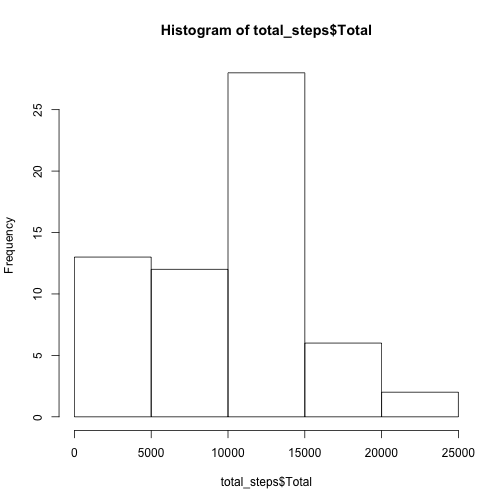

```r
total_steps <- aggregate(list(Total = data$steps), by=list(Date = data$date), FUN=sum, na.rm=TRUE)
hist(total_steps$Total)
```

1. Calculate and report the mean and median total number of steps taken per day

```r
mean_steps <- aggregate(list(Mean = data$steps), by=list(Date = data$date), FUN=mean, na.rm=TRUE)
mean_steps
```

```
##          Date       Mean
## 1  2012-10-01        NaN
## 2  2012-10-02  0.4375000
## 3  2012-10-03 39.4166667
## 4  2012-10-04 42.0694444
## 5  2012-10-05 46.1597222
## 6  2012-10-06 53.5416667
## 7  2012-10-07 38.2465278
## 8  2012-10-08        NaN
## 9  2012-10-09 44.4826389
## 10 2012-10-10 34.3750000
## 11 2012-10-11 35.7777778
## 12 2012-10-12 60.3541667
## 13 2012-10-13 43.1458333
## 14 2012-10-14 52.4236111
```

[output cut: 47 more lines]

```r
median_steps <- aggregate(list(Median = data$steps), by=list(Date = data$date), FUN=median, na.rm=TRUE)
median_steps
```

```
##          Date Median
## 1  2012-10-01     NA
## 2  2012-10-02      0
## 3  2012-10-03      0
## 4  2012-10-04      0
## 5  2012-10-05      0
## 6  2012-10-06      0
## 7  2012-10-07      0
## 8  2012-10-08     NA
## 9  2012-10-09      0
## 10 2012-10-10      0
## 11 2012-10-11      0
## 12 2012-10-12      0
## 13 2012-10-13      0
## 14 2012-10-14      0
```

[output cut: 47 more lines]

## What is the average daily activity pattern?

1. Make a time series plot (i.e. type = “l”) of the 5-minute interval (x-axis) and the average number of steps taken, averaged across all days (y-axis)

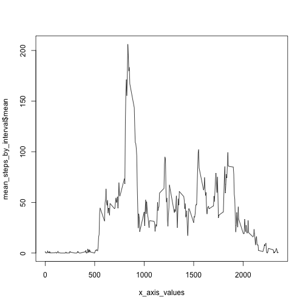

```r
x_axis_values <- data[data$date=="2012-10-04",3]
mean_steps_by_interval <- aggregate(list(mean = data$steps), by=list(interval = data$interval), FUN=mean, na.rm=TRUE)
plot(x_axis_values, mean_steps_by_interval$mean, type="l")
```

1. Which 5-minute interval, on average across all the days in the dataset, contains the maximum number of steps?

```r
x_axis_values[which.max(mean_steps_by_interval$mean)]
```

```
## [1] 835
```

## Imputing missing values

1. Calculate and report the total number of missing values in the dataset (i.e. the total number of rows with NAs)

```r
sum(is.na(data$steps))
```

```
## [1] 2304
```

1. Devise a strategy for filling in all of the missing values in the dataset. The strategy does not need to be sophisticated. For example, you could use the mean/median for that day, or the mean for that 5-minute interval, etc.

*For missing step values, a value will be set that is equivalent to the mean value for that interval as taken across all days for that interval*

1. Create a new dataset that is equal to the original dataset but with the missing data filled in.

```r
interpreted_data <- data

for (i in 1:length(interpreted_data$steps)) {

  if(is.na(interpreted_data[i,]$steps)){
      interpreted_data[i,]$steps = mean_steps_by_interval[mean_steps_by_interval$interval == interpreted_data[i,]$interval,2]
    }
}
```

1. Make a histogram of the total number of steps taken each day and Calculate and report the mean and median total number of steps taken per day.

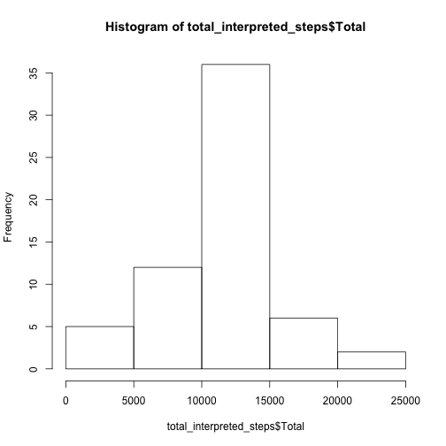

```r
total_interpreted_steps <- aggregate(list(Total = interpreted_data$steps), by=list(Date = data$date), FUN=sum, na.rm=TRUE)
hist(total_interpreted_steps$Total)
```

```r
interpreted_mean_steps <- aggregate(list(Mean = interpreted_data$steps), by=list(Date = interpreted_data$date), FUN=mean, na.rm=TRUE)
interpreted_mean_steps
```

```
##          Date       Mean
## 1  2012-10-01 37.3825996
## 2  2012-10-02  0.4375000
## 3  2012-10-03 39.4166667
## 4  2012-10-04 42.0694444
## 5  2012-10-05 46.1597222
## 6  2012-10-06 53.5416667
## 7  2012-10-07 38.2465278
## 8  2012-10-08 37.3825996
## 9  2012-10-09 44.4826389
## 10 2012-10-10 34.3750000
## 11 2012-10-11 35.7777778
## 12 2012-10-12 60.3541667
## 13 2012-10-13 43.1458333
## 14 2012-10-14 52.4236111
```

[output cut: 47 more lines]

```r
interpreted_median_steps <- aggregate(list(Median = interpreted_data$steps), by=list(Date = interpreted_data$date), FUN=median, na.rm=TRUE)
interpreted_median_steps
```

```
##          Date   Median
## 1  2012-10-01 34.11321
## 2  2012-10-02  0.00000
## 3  2012-10-03  0.00000
## 4  2012-10-04  0.00000
## 5  2012-10-05  0.00000
## 6  2012-10-06  0.00000
## 7  2012-10-07  0.00000
## 8  2012-10-08 34.11321
## 9  2012-10-09  0.00000
## 10 2012-10-10  0.00000
## 11 2012-10-11  0.00000
## 12 2012-10-12  0.00000
## 13 2012-10-13  0.00000
## 14 2012-10-14  0.00000
```

[output cut: 47 more lines]

## Are there differences in activity patterns between weekdays and weekends?

1. Create a new factor variable in the dataset with two levels – “weekday” and “weekend” indicating whether a given date is a weekday or weekend day.

```r
if(!require(timeDate)){
  install.packages("timeDate")
}
library(timeDate)

interpreted_data$isWeekday = as.factor(ifelse(isWeekday(interpreted_data$date), "weekday", "weekend"))
```

1. Make a panel plot containing a time series plot (i.e. type = “l”) of the 5-minute interval (x-axis) and the average number of steps taken, averaged across all weekday days or weekend days (y-axis).

```r
mean_steps <- aggregate(list(mean = interpreted_data$steps), by=list(interval = interpreted_data$interval, isWeekday = interpreted_data$isWeekday), FUN=mean, na.rm=TRUE)

if(!require(lattice)){
  install.packages("lattice")
}
```

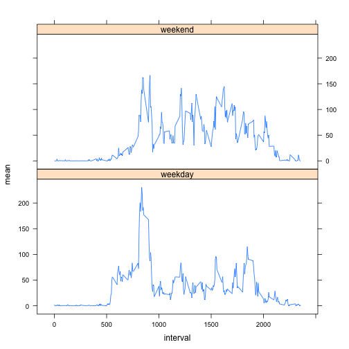

```r
library(lattice)

xyplot(mean ~ interval | factor(isWeekday), data = mean_steps, type="l", layout=c(1,2))
```